# Bio 302 Exam 2020

Tage Vestlie

15 June 2021

## Questions

1. Discuss the advantages and challenges of pre-registering an experiment.
2. Discuss the steps you plan to use to make your thesis reproducible.
3. A statistical test has a p-value of 0.04.
- How should this p-value be interpreted?
- Is it good evidence against the null hypothesis?
4. A graduate student got this advice from their supervisor: “Just make a giant correlation matrix and see what is interesting”. Discuss the potential problems with this approach and how they could be resolved.
5. Explain what autocorrelation is, how it can be detected and how its effect on regression can be controlled for.
6. Model the relationship between total plant biomass in alpine grasslands and summer air temperature in China. Available data are biomass per species per plot. There are ~15 plots in each of four sites. Each site is at a different elevation and has a climate logger.

```r
library(tidyverse)
library(readxl)
library(lubridate)
library(scales)
```

- Climate data can be downloaded from https://osf.io/34qnr/

```r
airtemp_file <- ("China_2013_2016_AirTemp_month.csv")
airtemp <- read.csv(airtemp_file)
```

- Biomass data can be downloaded from https://osf.io/6sfqw/ (you already have these).

```r
biomass_file <- excel_sheets("Biomass2015.xls") %>%
  map_dfr(~ read_excel("Biomass2015.xls", sheet = .x))
```

- Calculate mean summer air temperatures each site. Use the logger “gradient”. The OTC logger is part of another experiment.

```r
airtemp <- airtemp %>%
  rename (date = month) %>%
  rename (temperature = value)

airtemp_mean <- airtemp %>%
  filter(logger == "gradient") %>%
  separate(col = date, into = c("year","date","day" ))%>%
  filter(date %in% c("06","07","08"))%>%
  group_by(site) %>%
  summarise(summer_temp = mean(temperature, na.rm = T)) %>%
  ungroup() %>%
  arrange(site)

View(airtemp_mean)
```

- Calculate biomass per plot (you have already done this).

```r
mergedata_df <-
  biomass_file %>%
  group_by(plot,site) %>%
  summarise(total_production = sum (production, na.rm = T)) %>%
  ungroup()
View(mergedata_df)
```

- Join the climate data to the biomass data.

```r
biomass_temperature <- mergedata_df %>%
  left_join(airtemp_mean, by = "site") %>%
  mutate(summer_temp_sq = summer_temp^2)

View(biomass_temperature)
```

- Choose and fit a suitable model to find the relation a biomass and mean summer temperature.

```r
df_lm <- lm(total_production ~ summer_temp + summer_temp_sq, biomass_temperature) ## have to write about why i added the summer_temp_sq

summary(df_lm)
```

```
##
## Call:
## lm(formula = total_production ~ summer_temp + summer_temp_sq,
##     data = biomass_temperature)
##
## Residuals:
##     Min      1Q  Median      3Q     Max
## -38.195 -15.528  -2.225  12.212  55.205
##
## Coefficients:
##                 Estimate Std. Error t value Pr(>|t|)
## (Intercept)    -403.0155    73.9347  -5.451 7.07e-07 ***
## summer_temp      97.4906    16.2207   6.010 7.51e-08 ***
## summer_temp_sq   -4.8694     0.8622  -5.647 3.24e-07 ***
## ---
## Signif. codes:  0 '***' 0.001 '**' 0.01 '*' 0.05 '.' 0.1 ' ' 1
##
## Residual standard error: 20.78 on 70 degrees of freedom
## Multiple R-squared:  0.4348, Adjusted R-squared:  0.4187
## F-statistic: 26.93 on 2 and 70 DF,  p-value: 2.122e-09
```

- Check the model’s assumptions are met.

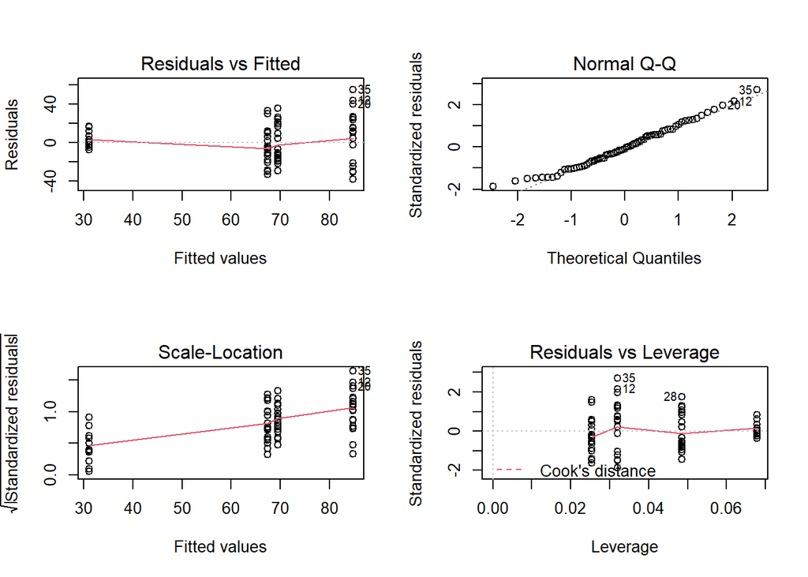

```r
# creating diagnostik plots
x11()
par(mfrow=c(2,2))
plot(df_lm)
```

- Report key statistics from your model in a table or in the text.
- Make a publication quality plot that shows the relationship between biomass and mean summer temperature.

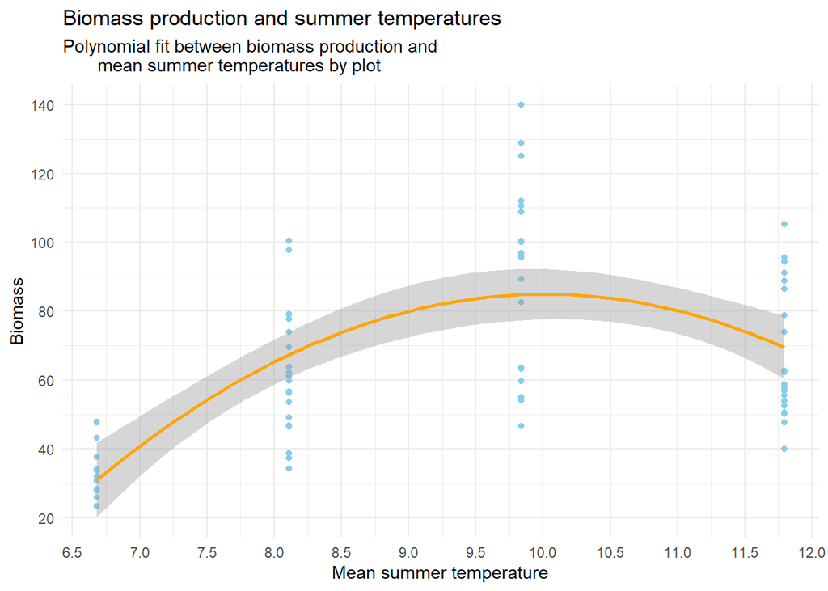

```r
biomass_temperature %>%
  ggplot(aes(x = summer_temp, y = total_production)) +
  geom_point(color = "skyblue") +
  geom_smooth(method = lm,
              formula = y~ poly(x, 2), #adding the polynomial because of the "fall# of biomass at higher temperatures, straight line did not fit as well
              color = "orange") +
  #cleaner theme
  theme_minimal() +
  #chaning the labels
  labs(title = "Biomass production and summer temperatures",
       subtitle = "Polynomial fit between biomass production and
       mean summer temperatures by plot",
       x = "Mean summer temperature",
       y = "Biomass") +
  scale_y_continuous(breaks = pretty_breaks(n = 5)) +# adding more numbers to the y-axis
  scale_x_continuous(breaks = pretty_breaks(n = 10)) # adding more numbers to the x-axis
```

- Write the statistical part of the methods and results sections of a manuscript describing the biomass-climate relationship. You should justify your choice of model.

- Write a biological interpretation of your final model.
- Your manuscript should be fully reproducible. That is, I should be able to render your rmarkdown file and generate all results.

## Instructions

Please answer all questions. Please do not google-copy-paste answers - I will check for plagiarism.

Your answers should be fully reproducible and include publication quality graphics where relevant. Submit as html or pdf and include the Rmarkdown file.

If there are problems, please ask me richard.telford@uib.no